# Part II - Explanatory analyze of Bike-sharing data

## by Evgeniy Kuryan

## Investigation Overview

Questions to this data that need to be answered:

1. When are most trips taken in terms day of the week, number of week or month of the year
2. How long does the average trip take?
3. Does the above depend on if a user is a subscriber or customer?
4. Which stations are most highly loaded and which are not?

## Dataset Overview

This data set includes information about individual rides made in a bike-sharing system covering the greater San Francisco Bay area. Original data have 183412 rows and 16 columns with information: 'duration_sec', 'start_time', 'end_time', 'start_station_id', 'start_station_name', 'start_station_latitude', 'start_station_longitude', 'end_station_id', 'end_station_name','end_station_latitude', 'end_station_longitude', 'bike_id', 'user_type', 'member_birth_year', 'member_gender', 'bike_share_for_all_trip'. There are some mistakes in data such as wrong birth data for subscribers, but they are not crucial for our observations.

## (Visualization 1)

All trips were started in February 2019. 16 trips started in February and were completed in March 2019. Most rides were done at week number 8. In our data, we have complete information about 3 weeks (week number 6,7,8), weeks 5 and 9 represented partly.

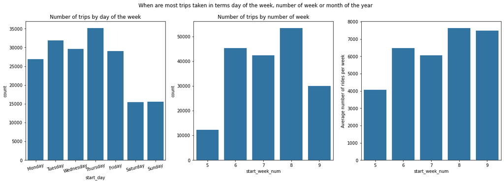

## (Visualization 2)

Almost 90% of rides was done by subscribers (exact value = 89,17%)

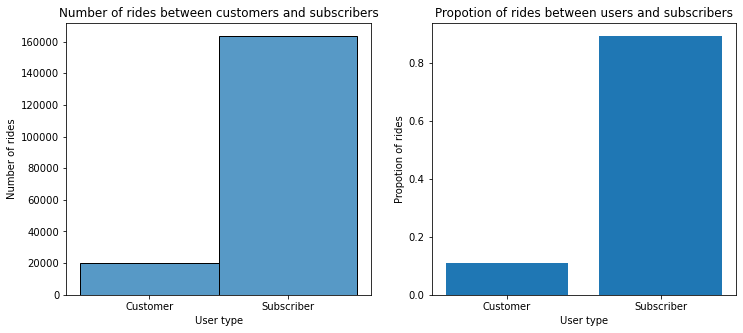

## (Visualization 3)

Average duration for subscriber trip is 640 second, and for Customer: 1432 seconds. Average duration of trip at all is 726 seconds.

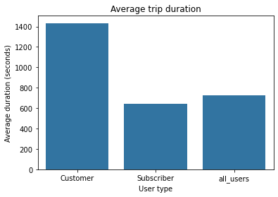

## (Visualization 4)

The average trip duration on weekends is higher than on weekdays. Our customers prefer long trips on weekends, but the duration of the trips for subscribers is practically independent of weekends or weekdays. Also, there are practically no relations between the number of rides and day of the week for our customers, but our subscribers mostly use our bikes on weekdays. This information can be used in planning a marketing campaign to increase the use of our bicycles on unloaded days.

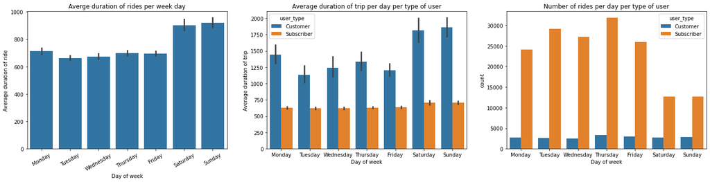

## Visualization 5

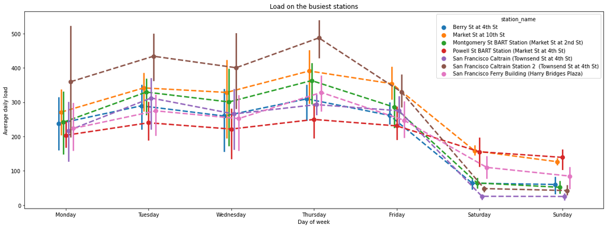

## Visualization 6.1

Let's see the locations of our station, their monthly load, and how they could be grouped by the location.

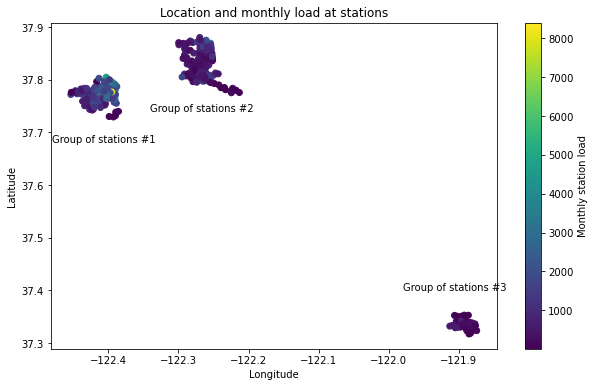

### Visualization 6.2

The heavily loaded stations serve around 300 visits per day, while there are many stations with less than 4 visits per day. Let's see how it looks.

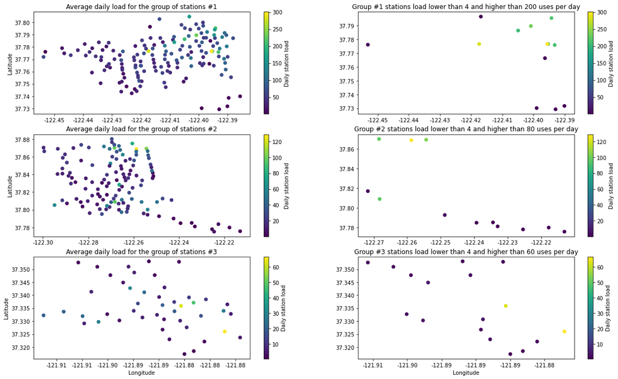